# Data Camp Python Notes (Visualization)

**Example #1: Multiple Time Series on a Single Plot**:

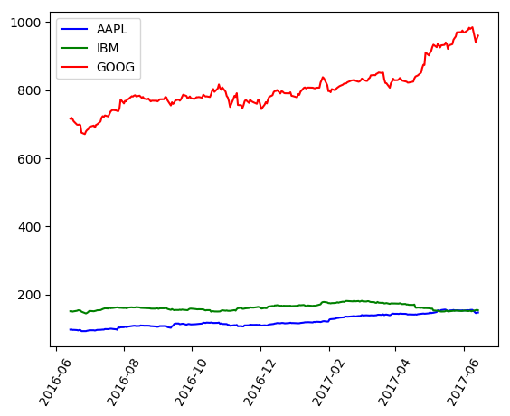

**Example #2: Multiple Time Series on Separate Sub-Plots**:

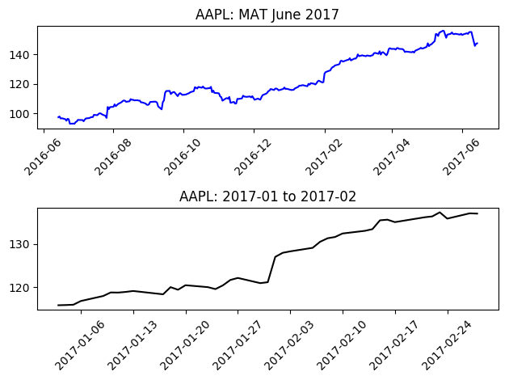

**Example #3: Multiple Time Series on Separate Sub-Plots**:

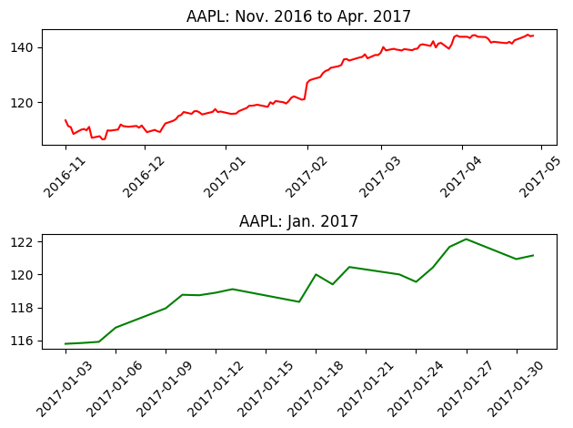

**Example #4: Multiple Time Series as Callout on Single Main Plot**:

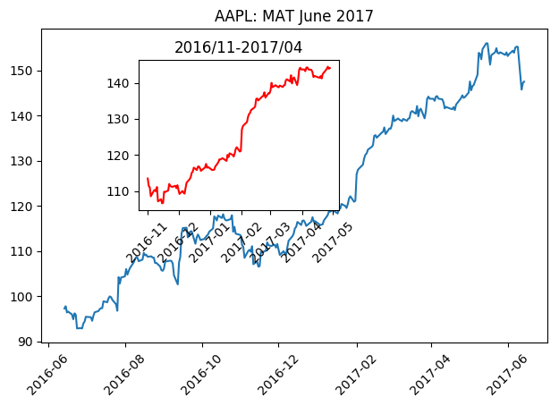

**Example #5: Rolling Mean Stock Prices (AAPL 10-d, 30-d, 75-d, 125-d)**:

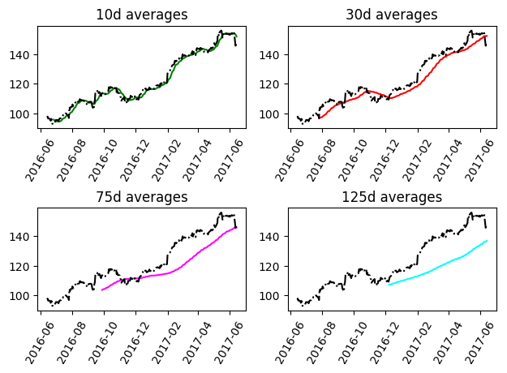

**Example #6: Rolling Standard Deviation of Stock Prices (AAPL 10-d, 30-d, 75-d, 125-d)**:

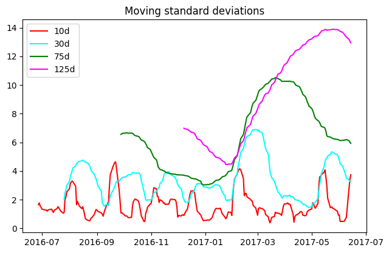

**Example #7: Grayscale Image and Pixel Histogram**:

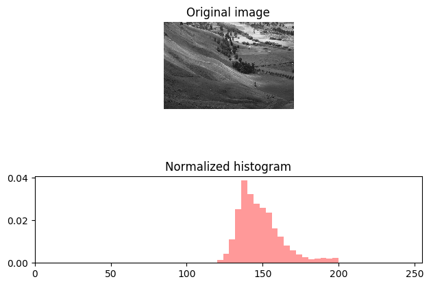

**Example #8: Grayscale Image and Pixel CDF/PDF**:

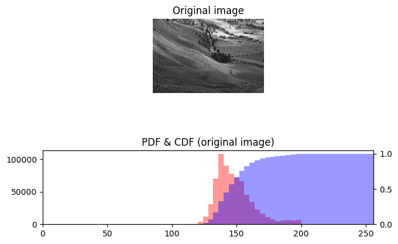

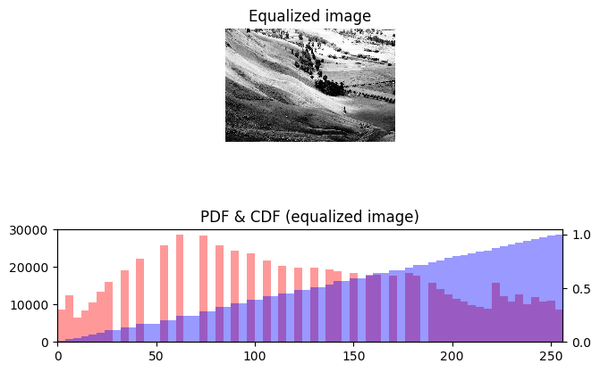

### *Interactive Data Visualization with Bokeh*

Chapter 1 - Basic plotting with Bokeh

Plotting with glyphs - visual shapes that can be drawn to the screen (line, points, rectangles, etc.):

- Glyphs may have many properties - coordinates, size, color, transparency (alpha), etc.
- General usage includes “from bokeh.io import output_file, show” AND “from bokeh.plotting import figure”
  - plot = figure(width=400, tools=“pan,box_zoom”)
  - plot.circle([1, 2, 3, 4, 5], [8, 6, 5, 2, 3])
  - output_file(“circle.html”)
  - show(plot)
- Can set glyph properties using lists, arrays, sequences, etc.
  - Can also set glyph values using a single fixed value, which will be propagated to all glyphs
  - There are many default values that will be applied if not supplied

Additional glyphs - available by default in Bokeh:

- Lines can be created using the .line() method for a Bokeh figure
- Glyphs will be drawn in the method called, so circles on top of lines can be generated with .line() followed later by .circle()
- Patches can be useful for drawing geographic regions
  - Data is provided to patches as a list of lists - one list has the patch X coordinates and another list has the patch y coordinates
  - xs = [ [1, 1, 2, 2] , [2, 2, 4] , [2, 2, 3, 3] ]
  - ys = [ [2, 5, 5, 2] , [3, 5, 5] , [2, 3, 4, 2] ]
  - plot = figure() ; plot.patches(xs, ys, fill_color=[“red”, “blue”, “green”], line_color=“white”)
- While not covered in this course, there are many other types of glyphs - see the documentation for Bokeh

Data formats - can pass lists, NumPy arrays, etc. as inputs to the glyphs:

- Can pass the 1D NumPy arrays directly to the x and y arguments for Bokeh
- Can also use pandas DataFrames, using the standard x[“myVar”] to pull out the DataSeries of interest
  - There appears to be a bokeh.sampledata that may have some of the standard datasets such as iris
- Column Data Source - underlies most of the data structures in Bokeh
  - Dictionaries for mapping string column names to sequences of data ; often created automatically
  - Can be beneficial to create a Column Data Source directly - pass to multiple glyphs to link selections, enable use during hovering, etc.
  - from bokeh.models import ColumnDataSource
  - source = ColumnDataSource(data={“x”:[] , “y”:[]}) # just an example . . . All columns in the ColumnDataSource() must be the same length . . .
  - An additional idea is to run a = ColumnDataSource(myDF), with a now being available anywhere as a ColumnDataSource()

Customizing glyphs - actions in response to hovering, user clicks, etc.:

- The tools are generally added as arguments to the figure(tools=“box_select, lasso_select”) function
  - Arguments for what to do with “non-selected” points can be passed to the glyph
  - plot.circle(x, y, selection_color=“red”, nonselection_fill_alpha = 0.2, nonselection_fill_color=“grey”) # color is short-hand for fill_color and line_color
- Hovering is more sophisticated and governs how the glyphs will react when hovered over
  - from bokeh.models import HoverTool
  - hover = HoverTool(tooltips=None, mode=“hline”)
  - plot = figure(tools=[hover, “crosshair”])
  - plot.circle(x, y, size=15, hover_color=“red”)
- Color mapping - for example, colors by Species in the “iris” dataset
  - from bokeh.models import CategoricalColorMapper
  - mapper = CategoricalColorMapper( factors=[“setosa”, “virginica”, “versicolor”], palette=[“red”, “green”, “blue”])
  - plot.circle(“x”, “y”, source=source, color={“field”:“species”, “transform”:mapper})

Example code includes:

```python
myPath = "./PythonInputFiles/"



# Import figure from bokeh.plotting
from bokeh.plotting import figure

# Import output_file and show from bokeh.io
from bokeh.io import output_file, show


import pandas as pd
rawGap = pd.read_csv(myPath + "literacy_birth_rate.csv", index_col=None)
fertility = rawGap["fertility"]
female_literacy = rawGap["female literacy"]


# Create the figure: p
p = figure(x_axis_label='fertility (children per woman)', y_axis_label='female_literacy (% population)')

# Add a circle glyph to the figure p
p.circle(fertility, female_literacy)

# Call the output_file() function and specify the name of the file
output_file(myPath + "fert_lit.html")

# Display the plot
# show(p)


# Create the figure: p
p = figure(x_axis_label='fertility', y_axis_label='female_literacy (% population)')

fertility_latinamerica = fertility[rawGap["Continent"] == "LAT"]
female_literacy_latinamerica = female_literacy[rawGap["Continent"] == "LAT"]

# Add a circle glyph to the figure p
p.circle(fertility_latinamerica, female_literacy_latinamerica)

fertility_africa = fertility[rawGap["Continent"] == "AF"]
female_literacy_africa = female_literacy[rawGap["Continent"] == "AF"]

# Add an x glyph to the figure p
p.x(fertility_africa, female_literacy_africa)

# Specify the name of the file
output_file(myPath + 'fert_lit_separate.html')

# Display the plot
# show(p)


# Create the figure: p
p = figure(x_axis_label='fertility (children per woman)', y_axis_label='female_literacy (% population)')

# Add a blue circle glyph to the figure p
p.circle(fertility_latinamerica, female_literacy_latinamerica, color="blue", size=10, alpha=0.8)

# Add a red circle glyph to the figure p
p.circle(fertility_africa, female_literacy_africa, color="red", size=10, alpha=0.8)

# Specify the name of the file
output_file(myPath + 'fert_lit_separate_colors.html')

# Display the plot
# show(p)


# AAPL share price - 2000 to 2014
from datetime import datetime

aaplRaw = pd.read_csv(myPath + "aapl_2000_2014.csv", index_col=0)
date = [datetime.strptime(x, "%Y-%m-%d") for x in aaplRaw["date"]]
price = aaplRaw["adj_close"]

# Import figure from bokeh.plotting
from bokeh.plotting import figure

# Create a figure with x_axis_type="datetime": p
p = figure(x_axis_type="datetime", x_axis_label='Date', y_axis_label='US Dollars')

# Plot date along the x axis and price along the y axis
p.line(date, price)

# Specify the name of the output file and show the result
output_file(myPath + 'line.html')
# show(p)


# Import figure from bokeh.plotting
from bokeh.plotting import figure

# Create a figure with x_axis_type='datetime': p
p = figure(x_axis_type='datetime', x_axis_label='Date', y_axis_label='US Dollars')

# Plot date along the x-axis and price along the y-axis
p.line(date, price)

# With date on the x-axis and price on the y-axis, add a white circle glyph of size 4
p.circle(date, price, fill_color="white", size=4)

# Specify the name of the output file and show the result
output_file(myPath + 'line.html')
# show(p)


# Create a list of az_lons, co_lons, nm_lons and ut_lons: x
# x = [az_lons, co_lons, nm_lons, ut_lons]

# Create a list of az_lats, co_lats, nm_lats and ut_lats: y
# y = [az_lats, co_lats, nm_lats, ut_lats]

# Add patches to figure p with line_color=white for x and y
# p.patches(x, y, line_color="white")

# Specify the name of the output file and show the result
# output_file('four_corners.html')
# show(p)


# Import numpy as np
import numpy as np

# Create array using np.linspace: x
x = np.linspace(0, 5, 100)

# Create array using np.cos: y
y = np.cos(x)

# Add circles at x and y
p.circle(x, y)

# Specify the name of the output file and show the result
output_file(myPath + 'numpy.html')
# show(p)


# Import pandas as pd
import pandas as pd

# Read in the CSV file: df
df = pd.read_csv(myPath + "auto-mpg.csv")

# Import figure from bokeh.plotting
from bokeh.plotting import figure

# Create the figure: p
p = figure(x_axis_label='HP', y_axis_label='MPG')

# Plot mpg vs hp by color
p.circle(df["hp"], df["mpg"], size=10, color=df["color"])

# Specify the name of the output file and show the result
output_file(myPath + 'auto-df.html')
# show(p)


# Import the ColumnDataSource class from bokeh.plotting
from bokeh.plotting import ColumnDataSource

# Create a ColumnDataSource from df: source
source = ColumnDataSource(df)

# Add circle glyphs to the figure p
p.circle("yr", "accel", source=source, color="color", size=8)

# Specify the name of the output file and show the result
output_file(myPath + 'sprint.html')
# show(p)


# Create a figure with the "box_select" tool: p
p = figure(x_axis_label="Year", y_axis_label="Accel", tools="box_select")

# Add circle glyphs to the figure p with the selected and non-selected properties
p.circle("yr", "accel", source=source, selection_color="red", nonselection_alpha=0.1)

# Specify the name of the output file and show the result
output_file(myPath + 'selection_glyph.html')
# show(p)


# import the HoverTool
# from bokeh.models import HoverTool

# Add circle glyphs to figure p
# p.circle(x, y, size=10,
#          fill_color="grey", alpha=0.1, line_color=None,
#          hover_fill_color="firebrick", hover_alpha=0.5,
#          hover_line_color="white")

# Create a HoverTool: hover
# hover = HoverTool(tooltips=None, mode="vline")

# Add the hover tool to the figure p
# p.add_tools(hover)

# Specify the name of the output file and show the result
# output_file(myPath + 'hover_glyph.html')
# show(p)


#Import CategoricalColorMapper from bokeh.models
from bokeh.models import CategoricalColorMapper

# Convert df to a ColumnDataSource: source
source = ColumnDataSource(df)

# Make a CategoricalColorMapper object: color_mapper
color_mapper = CategoricalColorMapper(factors=['Europe', 'Asia', 'US'],
                                      palette=['red', 'green', 'blue'])

# Add a circle glyph to the figure p
p.circle("weight", 'mpg', source=source,
            color=dict(field='origin', transform=color_mapper),
            legend='origin')

# Specify the name of the output file and show the result
output_file(myPath + 'colormap.html')
# show(p)
```

Chapter 2 - Layouts, Interactions, and Annotations

Introduction to Layouts - annotations, links across plots, etc.:

- Placing plots in rows and columns
  - from bokeh.layouts import row # can alternately run ‘from bokeh.layouts import column’ and then ’layout = column(p1, p2, p3)
  - layout = row(p1, p2, p3) # assumes that p1, p2, and p3 have already been created as desired using figure() and something like .circle() or .line() or the like
  - Can also nest the columns and rows, such as layout = row(column(p1, p2), p3)

Advanced Layouts - continuing with gridded layouts and tabbed layouts:

- Gridded arrangements - start with ‘from bokeh.layouts import gridplot’
  - The arguments to gridplot include a list of lists, with each list being a row (as such, the inner lists need to all be the same length)
  - There is then a single master toolbar that will zoom/pan on all the gridded data at once; set toolbar_location = None to override this, or specify a preferred location
  - layout = gridplot([[None, p1], [p2, p3]], toolbar_location = None)
- Tabbed layouts - creating a panel for each tab, then collecting all of the tabs in to a tabbed object
  - from bokeh.models.widgets import Tabs, Panel
  - first = Panel(child=row(p1, p2), title=“first”) # child can be just about anything - single plot, grid, whatever
  - second = Panel(child=row(p3), title=“second”) # child can be just about anything - single plot, grid, whatever
  - tabs = Tabs(tabs=[first, second])
  - The final output will then be two tabs, allowing the user to click between a tab with p1, p2 and a tab with p3

Linking plots together - for example, keeping the ranges of two plots synchronized (even when panning or zooming occurs):

- To link together the x_axes, run a command like p3.x_range = p2.x_range = p1.x_range
- To link together the y_axes, run a command like p3.y_range = p2.y_range = p1.y_range
- To link to a common data source, run source = CommonDataSource(myDF), and then source=source in all of the plots - data will be the same, and can pick/choose columns as needed
  - This seems to mean that when highlighting occurs on one of the plots, the corresponding data in the other plots are also highlighted
  - “Linked brushing” seems to be the term for having the data linked in this fashion

Annotations and guides - better communicate findings from the data:

- Guides - helping to relate scale information to viewers
  - Axes and Grids - typically, Bokeh defaults are reasonably solid for these already (not covered further in this course)
- Legends serve as a common type of “guide” that explains the visual encodings
  - The simplest way to install the legend would be p1.legend.location = “top_left” # assume that p1 is already created using figure() and something like .circle(legend=“species”) if the desired legend is species
- “Hover Tooltips” offer a way for people to drill down in to details that are otherwise not visible on the plot
  - from bokeh.models import HoverTool
  - hover = HoverTool(tooltips=[ (“species name”, "@species"), (“petal length”, "@petal_length") ] ) # pass list of tuples to HoverTool(), with the “@” being a special symbol meaning “column of the ColumnDataSource”
  - plot = figure(tools=[hover, “pan”, “wheel_zoom”])

Example code includes:

```python
myPath = "./PythonInputFiles/"



# Import row from bokeh.layouts
from bokeh.layouts import row
from bokeh.plotting import ColumnDataSource, figure
from bokeh.io import output_file, show

import pandas as pd
rawGap = pd.read_csv(myPath + "literacy_birth_rate.csv", index_col=None)
rawGap.columns = ["Country", "Continent", "female_literacy", "fertility", "population"]


source = ColumnDataSource(rawGap)


# Create the first figure: p1
p1 = figure(x_axis_label='fertility (children per woman)', y_axis_label='female_literacy (% population)')

# Add a circle glyph to p1
p1.circle("fertility", "female_literacy", source=source)

# Create the second figure: p2
p2 = figure(x_axis_label='population', y_axis_label='female_literacy (% population)')

# Add a circle glyph to p2
p2.circle("population", "female_literacy", source=source)

# Put p1 and p2 into a horizontal row: layout
layout = row(p1, p2)

# Specify the name of the output_file and show the result
output_file(myPath + 'fert_row.html')
# show(layout)


# Import column from the bokeh.layouts module
from bokeh.layouts import column

# Create a blank figure: p1
p1 = figure(x_axis_label='fertility (children per woman)', y_axis_label='female_literacy (% population)')

# Add circle scatter to the figure p1
p1.circle('fertility', 'female_literacy', source=source)

# Create a new blank figure: p2
p2 = figure(x_axis_label="population", y_axis_label='female_literacy (% population)')

# Add circle scatter to the figure p2
p2.circle("population", "female_literacy", source=source)

# Put plots p1 and p2 in a column: layout
layout = column(p1, p2)

# Specify the name of the output_file and show the result
output_file(myPath + 'fert_column.html')
# show(layout)


# Import column and row from bokeh.layouts
from bokeh.layouts import row, column

# Make a column layout that will be used as the second row: row2
# row2 = column([mpg_hp, mpg_weight], sizing_mode='scale_width')

# Make a row layout that includes the above column layout: layout
# layout = row([avg_mpg, row2], sizing_mode='scale_width')

# Specify the name of the output_file and show the result
# output_file(myPath + 'layout_custom.html')
# show(layout)


# Import gridplot from bokeh.layouts
from bokeh.layouts import gridplot

# Create a list containing plots p1 and p2: row1
# row1 = [p1, p2]

# Create a list containing plots p3 and p4: row2
# row2 = [p3, p4]

# Create a gridplot using row1 and row2: layout
# layout = gridplot([row1, row2])

# Specify the name of the output_file and show the result
# output_file(myPath + 'grid.html')
# show(layout)


# Import Panel from bokeh.models.widgets
from bokeh.models.widgets import Panel

# Create a blank figure: p1
source = ColumnDataSource(rawGap.loc[rawGap["Continent"] == "LAT", :])
p1 = figure(x_axis_label='fertility (children per woman)', y_axis_label='female_literacy (% population)')
p1.circle('fertility', 'female_literacy', source=source)

source = ColumnDataSource(rawGap.loc[rawGap["Continent"] == "AF", :])
p2 = figure(x_axis_label='fertility (children per woman)', y_axis_label='female_literacy (% population)')
p2.circle('fertility', 'female_literacy', source=source)

source = ColumnDataSource(rawGap.loc[rawGap["Continent"] == "ASI", :])
p3 = figure(x_axis_label='fertility (children per woman)', y_axis_label='female_literacy (% population)')
p3.circle('fertility', 'female_literacy', source=source)

source = ColumnDataSource(rawGap.loc[rawGap["Continent"] == "EUR", :])
p4 = figure(x_axis_label='fertility (children per woman)', y_axis_label='female_literacy (% population)')
p4.circle('fertility', 'female_literacy', source=source)

source = ColumnDataSource(rawGap)

# Create tab1 from plot p1: tab1
tab1 = Panel(child=p1, title='Latin America')

# Create tab2 from plot p2: tab2
tab2 = Panel(child=p2, title='Africa')

# Create tab3 from plot p3: tab3
tab3 = Panel(child=p3, title='Asia')

# Create tab4 from plot p4: tab4
tab4 = Panel(child=p4, title='Europe')


# Import Tabs from bokeh.models.widgets
from bokeh.models.widgets import Tabs

# Create a Tabs layout: layout
layout = Tabs(tabs=[tab1, tab2, tab3, tab4])

# Specify the name of the output_file and show the result
output_file(myPath + 'tabs.html')
# show(layout)


# Link the x_range of p2 to p1: p2.x_range
p2.x_range = p1.x_range

# Link the y_range of p2 to p1: p2.y_range
p2.y_range = p1.y_range

# Link the x_range of p3 to p1: p3.x_range
p3.x_range = p1.x_range

# Link the y_range of p4 to p1: p4.y_range
p4.y_range = p1.y_range

# Specify the name of the output_file and show the result
output_file(myPath + 'linked_range.html')
# show(layout)


# Create ColumnDataSource: source
source = ColumnDataSource(rawGap)

# Create the first figure: p1
p1 = figure(x_axis_label='fertility (children per woman)', y_axis_label='female literacy (% population)',
            tools="box_select,lasso_select")

# Add a circle glyph to p1
p1.circle("fertility", "female_literacy", source=source)

# Create the second figure: p2
p2 = figure(x_axis_label='fertility (children per woman)', y_axis_label='population (millions)',
            tools="box_select,lasso_select")

# Add a circle glyph to p2
p2.circle("fertility", "population", source=source)

# Create row layout of figures p1 and p2: layout
layout = row(p1, p2)

# Specify the name of the output_file and show the result
output_file(myPath + 'linked_brush.html')
# show(layout)


# Add the first circle glyph to the figure p
# p.circle('fertility', 'female_literacy', source=latin_america, size=10, color="red", legend="Latin America")

# Add the second circle glyph to the figure p
# p.circle('fertility', 'female_literacy', source=africa, size=10, color="blue", legend="Africa")

# Specify the name of the output_file and show the result
# output_file(myPath + 'fert_lit_groups.html')
# show(p)


# Assign the legend to the bottom left: p.legend.location
# p.legend.location = "bottom_left"

# Fill the legend background with the color 'lightgray': p.legend.background_fill_color
# p.legend.background_fill_color = "lightgray"

# Specify the name of the output_file and show the result
# output_file(myPath + 'fert_lit_groups.html')
# show(p)


# Import HoverTool from bokeh.models
from bokeh.models import HoverTool

# Create a HoverTool object: hover
# hover = HoverTool(tooltips=[('Country','@Country')])

# Add the HoverTool object to figure p
# p.add_tools(hover)

# Specify the name of the output_file and show the result
# output_file(myPath + 'hover.html')
# show(p)
```

Chapter 3 - High-Level Charts

Pre-set interfaces to simlify chart design for common graphs like Histograms, Box-plots and Scatter-plots:

Histograms - start with “from bokeh.charts import Histogram”:

- Single histogram creation, including optionally specifying the number of bins
  - p = Histogram(myDF, “myColumn”, title=“myTitle”, bins=n) # note that myDF is a pandas DataFrame, and that a default number of bins will be selected if not specified
  - show(p)
- Multiple histogram creation, each colored by a factor variable
  - p = Histogram(myDF, “myColumn”, color=“myFactor”, title=“myTitle”, bins=n) # note that myDF is a pandas DataFrame, and that a default number of bins will be selected if not specified

BoxPlots - start with “from bokeh.charts import BoxPlot”:

- p = BoxPlot(df, values=“myQuantVariable”, label=“myGroupingVariable”, color=“myGroupingVariable”, title=“myTitle”) # label == color means each group will be colored differently
- show(p)

Scatter Plots - main advantage relative to using glyphs as per previous chapters is certain automation of grouping options:

- from bokeh.charts import Scatter
- p = Scatter(myDF, x=“myXColumn”, y=“myYColumn”, title=“myTitle”, color=“myColorVariable”, marker=“myMarkerVariable”) # color/marker is optional; by default, x and y become the axis labels also

Example code includes:

```python
myPath = "./PythonInputFiles/"



from bokeh.layouts import row
from bokeh.plotting import ColumnDataSource, figure
from bokeh.io import output_file, show

import pandas as pd
rawGap = pd.read_csv(myPath + "literacy_birth_rate.csv", index_col=None)
rawGap.columns = ["Country", "Continent", "female_literacy", "fertility", "population"]


source = ColumnDataSource(rawGap)


# Import Histogram, output_file, and show from bokeh.charts
from bokeh.charts import Histogram, output_file, show

# Make a Histogram: p
p = Histogram(rawGap, "female_literacy", title="Female Literacy")

# Set the x axis label
p.xaxis.axis_label = ""

# Set the y axis label
p.yaxis.axis_label = ""

# Specify the name of the output_file and show the result
output_file(myPath + "histogram.html")
# show(p)


# Import Histogram, output_file, and show from bokeh.charts
from bokeh.charts import Histogram, output_file, show

# Make the Histogram: p
p = Histogram(rawGap, "female_literacy", title='Female Literacy', bins=40)

# Set axis labels
p.xaxis.axis_label = 'Female Literacy (% population)'
p.yaxis.axis_label = 'Number of Countries'

# Specify the name of the output_file and show the result
output_file(myPath + 'histogram.html')
# show(p)


# Import Histogram, output_file, and show from bokeh.charts
from bokeh.charts import Histogram, output_file, show

# Make a Histogram: p
p = Histogram(rawGap, "female_literacy", title='Female Literacy',
              color="Continent", legend="top_left")

# Set axis labels
p.xaxis.axis_label = 'Female Literacy (% population)'
p.yaxis.axis_label = 'Number of Countries'

# Specify the name of the output_file and show the result
output_file(myPath + 'hist_bins.html')
# show(p)


# Import BoxPlot, output_file, and show from bokeh.charts
from bokeh.charts import BoxPlot, output_file, show

# Make a box plot: p
p = BoxPlot(rawGap, values="female_literacy", label="Continent",
            title='Female Literacy (grouped by Continent)', legend='bottom_right')

# Set the y axis label
p.yaxis.axis_label = 'Female literacy (% population)'

# Specify the name of the output_file and show the result
output_file(myPath + 'boxplot.html')
# show(p)


# Import BoxPlot, output_file, and show
from bokeh.charts import BoxPlot, output_file, show

# Make a box plot: p
p = BoxPlot(rawGap, values="female_literacy", label='Continent', color="Continent",
            title='Female Literacy (grouped by Continent)', legend="bottom_right")

# Set y-axis label
p.yaxis.axis_label = 'Female literacy (% population)'

# Specify the name of the output_file and show the result
output_file(myPath + 'boxplot.html')
# show(p)


# Import Scatter, output_file, and show from bokeh.charts
from bokeh.charts import Scatter, output_file, show

# Make a scatter plot: p
p = Scatter(rawGap, x="population", y="female_literacy",
            title='Female Literacy vs Population')

# Set the x-axis label
p.xaxis.axis_label = "Population"

# Set the y-axis label
p.yaxis.axis_label = "Female Literacy"

# Specify the name of the output_file and show the result
output_file(myPath + 'scatterplot.html')
# show(p)


# Import Scatter, output_file, and show from bokeh.charts
from bokeh.charts import Scatter, output_file, show

# Make a scatter plot such that each circle is colored by its continent: p
p = Scatter(rawGap, x="population", y="female_literacy", color="Continent",
            title='Female Literacy vs Population')

# Set x-axis and y-axis labels
p.xaxis.axis_label = 'Population (millions)'
p.yaxis.axis_label = 'Female literacy (% population)'

# Specify the name of the output_file and show the result
output_file(myPath + 'scatterplot.html')
# show(p)


# Import Scatter, output_file, and show from bokeh.charts
from bokeh.charts import Scatter, output_file, show

# Make a scatter plot such that each continent has a different marker type: p
p = Scatter(rawGap, x="population", y="female_literacy", color="Continent", marker="Continent", title="Female Literacy vs. Population")

# Set x-axis and y-axis labels
p.xaxis.axis_label = 'Population (millions)'
p.yaxis.axis_label = 'Female literacy (% population)'

# Specify the name of the output_file and show the result
output_file(myPath + 'scatterplot.html')
# show(p)
```

Chapter 4 - Building Interactivity

Introducing the Bokeh Server - expanding from the default static html, js, etc.:

- Purpose of the Bokeh server is to connect user-inputs on the plot directly to a series of Python commands “behind the scenes”
  1. from bokeh.io import curdoc (This will hold everything that we create down the line)
  2. create plots and widgets
  3. Add callbacks
  4. Arrange plot and widgets in layouts
  5. curdoc().add_root(layout) (This loads the curdoc with everything we did in steps 2-4)
- Bokeh is run by way of shell or Windows command line - “bokeh serve –show myapp.py” # where ‘myapp.py’ is a stand-in for whatever the file happens to be
  - Alternately, to pull a full directory, “bokeh serve –show myappdir/

Connecting sliders to plots - frequently, the ColumnDataSource() is especially valuable for desired interactivity:

- Suppose that a plot=figure() ; plot.circle(…) has been created as well as slider=Slider(.)
- Next, define a function “callback” that has exactly three arguments “attr”, “old”, and “new” - so def callback(attr, old, new):
  - This function “callback” and the arguments “attr”, “old”, “new” should always be used - not the place to get creative with names, apparently
  - Can set N = slider.value to get the current value of the slider
  - Can set source.data = { } to update the data that is used as ColumnDataSource()
- Finally, link the function to the slider change using slider.on_change(“value”, callback) # The “value” means that we want to run whenever the “value” property of the slider changes
  - If setting layout = column(slider, plot) then the slider will be placed above the plot
- And, set curdoc().add_root(layout) to link the slider and plot from “layout” in to current working space

Updating plots from drop-downs - similar in many ways to setting up the sliders:

- Suppose that a plot=figure() ; plot.circle(…) has been created
- Bring in the drop-down capability, which is called “Select” ; “from bokeh.models import Select”
  - menu = Select(options=[“uniform”, “normal”, “lognormal”], value=“uniform”, title=“Distribution”) # sets up menu as a drop-down with 3 options and “uniform” the default/current choice
- Next, define a function “callback” that must still have exactly three arguments - “attr”, “old”, and “new”
  - Can define a function f based on menu.value, such as if menu.value == “uniform”: f=random
  - source.data = {“x”: f(size=N), “y”: f(size=N) }
- Lastly, link the drop-down to the data using menu.on_change(“value”, callback)
  - If setting layout = column(menu, plot) then the drop-down will be placed above the plot
- And, set curdoc().add_root(layout) to link the drop-down and plot from “layout” in to the current working space

Buttons are the third example of a Bokeh widget (many other examples available in the documentation):

- A primary difference with button clicks is that they are merely a yes/no event ; there is no inherent “value” to a button-click
- Bring in the buttons capability, which is called “Button”; “from bokeh.models import Button”
  - button = Button(label=“press me”)
- Next define a call-back function (which can actually have any name), with no arguments
  - Assign the function to do whatever you want upon the button click
- Lastly, link up the button-click to the data using button.on_click(callback) # or replace callback by the name of the function as defined above
- There are also other “button types” such as Toggle, CheckboxGroup, and RadioGroup - these have both an on/off and an associated value (so more like a drop-down)
  - Callbacks for these button types take a single argument, active

Hosting applications for wider audiences - can run locally or send to someone else (with code) for them to run locally:

- To make more broadly available, look at “Running Bokeh Server” for options
- Bokeh Applications can now also be run easily using Anaconda Cloud

Example code includes:

```python
myPath = "./PythonInputFiles/"



# Perform necessary imports
from bokeh.io import curdoc
from bokeh.plotting import ColumnDataSource, figure
from bokeh.layouts import row, column


# Create a new plot: plot
plot = figure()

# Add a line to the plot
plot.line([1,2,3,4,5], [2,5,4,6,7])

# Add the plot to the current document
curdoc().add_root(plot)


# Perform the necessary imports
from bokeh.io import curdoc
from bokeh.layouts import widgetbox
from bokeh.models import Slider

# Create a slider: slider
slider = Slider(title='my slider', start=0, end=10, step=0.1, value=2)

# Create a widgetbox layout: layout
layout = widgetbox(slider)

# Add the layout to the current document
curdoc().add_root(layout)


# Perform necessary imports
from bokeh.io import curdoc
from bokeh.layouts import widgetbox
from bokeh.models import Slider, Button

# Create first slider: slider1
slider1 = Slider(title="slider1", start=0, end=10, step=0.1, value=2)

# Create second slider: slider2
slider2 = Slider(title="slider2", start=10, end=100, step=1, value=20)

# Add slider1 and slider2 to a widgetbox
layout = widgetbox(slider1, slider2)

# Add the layout to the current document
curdoc().add_root(layout)


# Create ColumnDataSource: source
x = [1, 2, 3, 4, 5]
y = [2, 5, 4, 6, 7]
source = ColumnDataSource( data={"x":x , "y":y} )

# Add a line to the plot
plot.line("x", "y", source=source)

# Create a column layout: layout
layout = column(widgetbox(slider), plot)

# Add the layout to the current document
curdoc().add_root(layout)


# Define a callback function: callback
def callback(attr, old, new):

    # Read the current value of the slider: scale
    scale = slider.value

    # Compute the updated y using np.sin(scale/x): new_y
    new_y = np.sin(scale/x)

    # Update source with the new data values
    source.data = {'x': x, 'y': new_y}

# Attach the callback to the 'value' property of slider
slider.on_change("value", callback)

# Create layout and add to current document
layout = column(widgetbox(slider), plot)
curdoc().add_root(layout)


# Perform necessary imports
from bokeh.models import ColumnDataSource, Select


import pandas as pd
rawGap = pd.read_csv(myPath + "literacy_birth_rate.csv", index_col=None)
fertility = rawGap["fertility"]
female_literacy = rawGap["female literacy"]
population = rawGap["population"]


# Create ColumnDataSource: source
source = ColumnDataSource(data={
    'x' : fertility,
    'y' : female_literacy
})

# Create a new plot: plot
plot = figure()

# Add circles to the plot
plot.circle('x', 'y', source=source)

# Define a callback function: update_plot
def update_plot(attr, old, new):
    # If the new Selection is 'female_literacy', update 'y' to female_literacy
    if new == "female_literacy":
        source.data = {
            'x' : fertility,
            'y' : female_literacy
        }
    # Else, update 'y' to population
    else:
        source.data = {
            'x' : fertility,
            'y' : population
        }

# Create a dropdown Select widget: select
select = Select(title="distribution", options=["female_literacy", "population"], value="female_literacy")

# Attach the update_plot callback to the 'value' property of select
select.on_change("value", update_plot)

# Create layout and add to current document
layout = row(select, plot)
curdoc().add_root(layout)


# Create two dropdown Select widgets: select1, select2
select1 = Select(title='First', options=['A', 'B'], value='A')
select2 = Select(title='Second', options=['1', '2', '3'], value='1')

# Define a callback function: callback
def callback(attr, old, new):
    # If select1 is 'A'
    if select1.value == "A":
        # Set select2 options to ['1', '2', '3']
        select2.options = ['1', '2', '3']

        # Set select2 value to '1'
        select2.value = "1"
    else:
        # Set select2 options to ['100', '200', '300']
        select2.options = ['100', '200', '300']

        # Set select2 value to '100'
        select2.value = "100"

# Attach the callback to the 'value' property of select1
select1.on_change("value", callback)

# Create layout and add to current document
layout = widgetbox(select1, select2)
curdoc().add_root(layout)


# Create a Button with label 'Update Data'
button = Button(label="Update Data")

# Define an update callback with no arguments: update
def update():

    # Compute new y values: y
    y = np.sin(x) + np.random.random(N)

    # Update the ColumnDataSource data dictionary
    source.data = {"x":x, "y":y}

# Add the update callback to the button
button.on_click(update)

# Create layout and add to current document
layout = column(widgetbox(button), plot)
curdoc().add_root(layout)


# Import CheckboxGroup, RadioGroup, Toggle from bokeh.models
from bokeh.models import CheckboxGroup, RadioGroup, Toggle

# Add a Toggle: toggle
toggle = Toggle(button_type = "success", label="Toggle button")

# Add a CheckboxGroup: checkbox
checkbox = CheckboxGroup(labels=['Option 1', 'Option 2', 'Option 3'])

# Add a RadioGroup: radio
radio = RadioGroup(labels=['Option 1', 'Option 2', 'Option 3'])

# Add widgetbox(toggle, checkbox, radio) to the current document
curdoc().add_root(widgetbox(toggle, checkbox, radio))
```

Chapter 5 - Case Study

Putting it all together - basic plotting, high-level charts, and interactivity:

- Basic dataset will be from Gapminder (country dataset over time)
- Goal is to create an interactive graph where the user can select the year (slider), x-variable (drop-down), and y-variable (drop-down)

Starting the application - getting to a slider for year, with bubbles colored by continent, but with fixed x/y variables:

- Import necessary modules - remember to use “from bokeh.io import curdoc”
- Create plots and widgets
- Add callbacks
- Arrange plots and widgets in layouts
- curdoc().add_root(layout) # make all of the above active

Adding more interactivity to the application - adding drop-downs for x/y variables, and adding a HoverTool to identify the relevant countries:

- Reminder on HoverTool, which comes from ‘from bokeh.models import HoverTool’
  - hover = HoverTool(tooltips=[ (‘myLabel1’, '@myVar1') , (‘myLabel2’, '@myVar2') ]) # Passed as list of tuples, with the @ meaning “get this variable from the source data columns”
- Recall that adding tools to a figure is as simple as plot = figure(tools=[hover, “pan”, “wheel_zoom”])
- Recall that drop-downs are formed by way of Select(options=[], value=‘’, title=’’)
  - The drop-downs similarly have an .on_change(“value”, callback) method

Example code includes:

```python
myPath = "./PythonInputFiles/"



import pandas as pd

rawGap = pd.read_csv(myPath + "gapminder_tidy.csv", index_col="Year")


# Perform necessary imports
from bokeh.io import output_file, show
from bokeh.plotting import figure
from bokeh.models import HoverTool, ColumnDataSource, Select

# Make the ColumnDataSource: source
source = ColumnDataSource(data={
    'x'       : rawGap.loc[1970]["fertility"],
    'y'       : rawGap.loc[1970]["life"],
    'country' : rawGap.loc[1970]["Country"]
})

# Create the figure: p
p = figure(title='1970', x_axis_label='Fertility (children per woman)',
           y_axis_label='Life Expectancy (years)',
           plot_height=400, plot_width=700,
           tools=[HoverTool(tooltips='@country')]
           )

# Add a circle glyph to the figure p
p.circle(x='x', y='y', source=source)

# Output the file and show the figure
output_file(myPath + 'gapminder.html')
# show(p)


# Import the necessary modules
from bokeh.io import curdoc
from bokeh.models import ColumnDataSource
from bokeh.plotting import figure

# Make the ColumnDataSource: source
source = ColumnDataSource(data={
    'x'       : rawGap.loc[1970].fertility,
    'y'       : rawGap.loc[1970].life,
    'country' : rawGap.loc[1970].Country,
    'pop'     : (rawGap.loc[1970].population / 20000000) + 2,
    'region'  : rawGap.loc[1970].region
})

# Save the minimum and maximum values of the fertility column: xmin, xmax
xmin, xmax = min(rawGap.fertility), max(rawGap.fertility)

# Save the minimum and maximum values of the life expectancy column: ymin, ymax
ymin, ymax = min(rawGap.life), max(rawGap.life)

# Create the figure: plot
plot = figure(title='Gapminder Data for 1970', plot_height=400, plot_width=700,
              x_range=(xmin, xmax), y_range=(ymin, ymax))

# Add circle glyphs to the plot
plot.circle(x="x", y="y", fill_alpha=0.8, source=source)

# Set the x-axis label
plot.xaxis.axis_label ='Fertility (children per woman)'

# Set the y-axis label
plot.yaxis.axis_label = 'Life Expectancy (years)'

# Add the plot to the current document and add a title
curdoc().add_root(plot)
curdoc().title = 'Gapminder'


# Make a list of the unique values from the region column: regions_list
regions_list = rawGap.region.unique().tolist()

# Import CategoricalColorMapper from bokeh.models and the Spectral6 palette from bokeh.palettes
from bokeh.models import CategoricalColorMapper
from bokeh.palettes import Spectral6

# Make a color mapper: color_mapper
color_mapper = CategoricalColorMapper(factors=regions_list, palette=Spectral6)

# Add the color mapper to the circle glyph
plot.circle(x='x', y='y', fill_alpha=0.8, source=source,
            color=dict(field="region", transform=color_mapper), legend="region")

# Set the legend.location attribute of the plot to 'top_right'
plot.legend.location = 'top_right'

# Add the plot to the current document and add the title
curdoc().add_root(plot)
curdoc().title = 'Gapminder'


# Import the necessary modules
from bokeh.layouts import widgetbox, row
from bokeh.models import Slider

# Define the callback function: update_plot
def update_plot(attr, old, new):
    # set the `yr` name to `slider.value` and `source.data = new_data`
    yr = slider.value
    new_data = {
        'x'       : rawGap.loc[yr].fertility,
        'y'       : rawGap.loc[yr].life,
        'country' : rawGap.loc[yr].Country,
        'pop'     : (rawGap.loc[yr].population / 20000000) + 2,
        'region'  : rawGap.loc[yr].region,
    }
    source.data = new_data

# Make a slider object: slider
slider = Slider(start=1970, end=2010, step=1, value=1970, title="Year")

# Attach the callback to the 'value' property of slider
slider.on_change("value", update_plot)

# Make a row layout of widgetbox(slider) and plot and add it to the current document
layout = row(widgetbox(slider), plot)
curdoc().add_root(layout)


# Define the callback function: update_plot
def update_plot(attr, old, new):
    # Assign the value of the slider: yr
    yr = slider.value
    # Set new_data
    new_data = {
        'x'       : rawGap.loc[yr].fertility,
        'y'       : rawGap.loc[yr].life,
        'country' : rawGap.loc[yr].Country,
        'pop'     : (rawGap.loc[yr].population / 20000000) + 2,
        'region'  : rawGap.loc[yr].region,
    }
    # Assign new_data to: source.data
    source.data = new_data

    # Add title to figure: plot.title.text
    plot.title.text = 'Gapminder data for %d' % yr

# Make a slider object: slider
slider = Slider(start=1970, end=2010, step=1, value=1970, title="Year")

# Attach the callback to the 'value' property of slider
slider.on_change("value", update_plot)

# Make a row layout of widgetbox(slider) and plot and add it to the current document
layout = row(widgetbox(slider), plot)
curdoc().add_root(layout)


# Import HoverTool from bokeh.models
from bokeh.models import HoverTool

# Create a HoverTool: hover
hover = HoverTool(tooltips=[('Country', '@country')])

# Add the HoverTool to the plot
plot.add_tools(hover)

# Create layout: layout
layout = row(widgetbox(slider), plot)

# Add layout to current document
curdoc().add_root(layout)


# Define the callback: update_plot
def update_plot(attr, old, new):
    # Read the current value off the slider and 2 dropdowns: yr, x, y
    yr = slider.value
    x = x_select.value
    y = y_select.value
    # Label axes of plot
    plot.xaxis.axis_label = x
    plot.yaxis.axis_label = y
    # Set new_data
    new_data = {
        'x'       : rawGap.loc[yr][x],
        'y'       : rawGap.loc[yr][y],
        'country' : rawGap.loc[yr].Country,
        'pop'     : (rawGap.loc[yr].population / 20000000) + 2,
        'region'  : rawGap.loc[yr].region,
    }
    # Assign new_data to source.data
    source.data = new_data

    # Set the range of all axes
    plot.x_range.start = min(rawGap[x])
    plot.x_range.end = max(rawGap[x])
    plot.y_range.start = min(rawGap[y])
    plot.y_range.end = max(rawGap[y])

    # Add title to plot
    plot.title.text = 'Gapminder data for %d' % yr

# Create a dropdown slider widget: slider
slider = Slider(start=1970, end=2010, step=1, value=1970, title='Year')

# Attach the callback to the 'value' property of slider
slider.on_change('value', update_plot)

# Create a dropdown Select widget for the x data: x_select
x_select = Select(
    options=['fertility', 'life', 'child_mortality', 'gdp'],
    value='fertility',
    title='x-axis data'
)

# Attach the update_plot callback to the 'value' property of x_select
x_select.on_change('value', update_plot)

# Create a dropdown Select widget for the y data: y_select
y_select = Select(
    options=['fertility', 'life', 'child_mortality', 'gdp'],
    value='life',
    title='y-axis data'
)

# Attach the update_plot callback to the 'value' property of y_select
y_select.on_change('value', update_plot)

# Create layout and add to current document
layout = row(widgetbox(slider, x_select, y_select), plot)
curdoc().add_root(layout)
```